# Migrations & Instabilité Sociale

en Afrique Subsaharienne

M1 Économétrie 2025

2026-04-14

*“Everything is related to everything else,*  
*but near things are more related than distant things.”*

**— Waldo R. Tobler, 1970**

Les conflits armés en Afrique subsaharienne  
**se propagent-ils aux pays voisins via les migrations ?**

40 pays · 29 années · Économétrie spatiale de panel

## Pourquoi l’économétrie peut répondre

**La question est géographique**

Les conflits ne restent pas dans les frontières.  
Les réfugiés traversent des pays.  
Les armes circulent dans les réseaux régionaux.

→ Ignorer la **structure spatiale** biaise tous les estimateurs classiques

**Les 5 phases appliquées à notre projet**

| Phase | Notre projet |
| --- | --- |
| ① Spécification | DSDM spatial |
| ② Données | WDI · UCDP · Polity5 |
| ③ Estimation | MCO → SDM → DSDM |
| ④ Évaluation | Tests LM + Wald |
| ⑤ Prévision | Simulateur de chocs |

*Malinvaud (1966) : “l’art de l’économètre consiste à tirer le maximum d’informations des données disponibles.”*

## Les données

**40 pays · 29 années (1996–2024)**  
**1 160 observations**

| Variable | Source |
| --- | --- |
| Conflits / 100k hab | UCDP/GED |
| Stock migrants | WDI |
| PIB par tête | WDI |
| Gouvernance | Polity5 |
| Ressources | WDI |
| Distances | CEPII |

Forme **log-log** → coefficients = élasticités  
*(Zallé & Ouédraogo, 2021)*

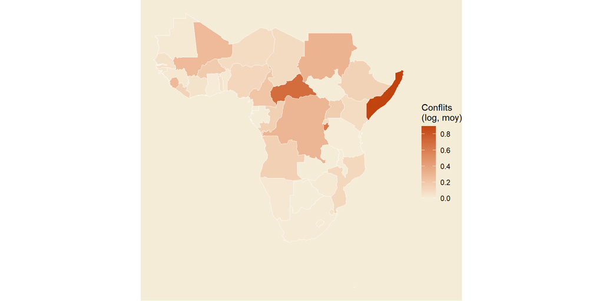

## ESDA — La dépendance spatiale existe

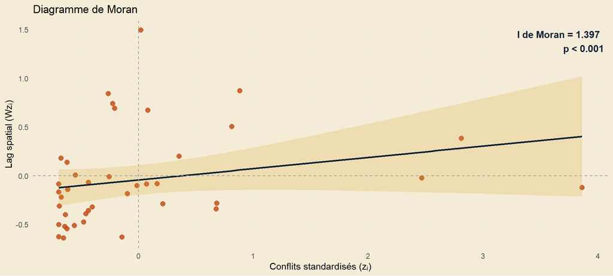

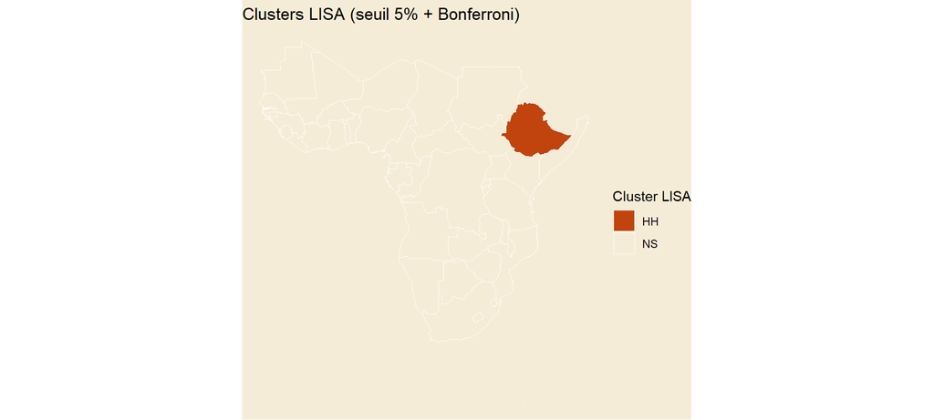

## De MCO au SDM — la chaîne d’arguments

[output not shown]

## DSDM — Modèle final

DSDM — W1 contiguïté, effets individuels

| Variable | Estimate | z-stat | Pr(>&#124;t&#124;) |
| --- | --- | --- | --- |
| lambda | -0.0224 | -0.663 | 0.506359 |
| lag_log_conflits | 0.7362 | 36.627 | < 2e-16 |
| lag_migrants | 0.0052 | 0.406 | 0.682731 |
| log_pib | 0.0239 | 0.872 | 0.381968 |
| polity2 | -0.0096 | -3.840 | 0.000135 |
| log_ressources | 0.0326 | 2.159 | 0.030580 |
| W_lag_migrants | 0.0477 | 2.083 | 0.037265 |
| W_log_pib | 0.0228 | 0.625 | 0.531365 |
| W_polity2 | -0.0004 | -0.103 | 0.925013 |
| W_log_ressources | -0.0290 | -1.266 | 0.204976 |

Note:  
z-statistiques (ML asymptotiquement normal, pas t-Student). *** p<0.001

## Effets Direct · Indirect · Total

**La décomposition fondamentale**

$$S_k(W) = (I - \rho W)^{-1}(I\beta_k + W\theta_k)$$

| Effet | Signification |
| --- | --- |
| **Direct** | Impact de $X_k$ du pays $i$ sur lui-même (avec feedbacks) |
| **Indirect** | Spillover vers les pays voisins |
| **Total** | Direct + Indirect |

⚠ **Toujours interpréter Direct, jamais Main**  
Main = paramètre brut  
Direct = effet marginal réel

**Lecture économique :**  
+1% de migrations dans le pays $i$  
→ $\hat\beta_{direct}$% de conflits dans $i$  
→ $\hat\theta_{indirect}$% de conflits dans les voisins de $i$

**C’est le spillover de Tobler rendu mesurable.**

## Robustesse & Conclusion

**3 tests de robustesse**

| Test | Résultat |
| --- | --- |
| W2 — inverse-distance | Signes stables ✓ |
| W3 — k=5 voisins | Signes stables ✓ |
| GMM Blundell-Bond | Sargan p > 0,10 ✓ |

**Limites à reconnaître**

- Corrélation ≠ causalité
- Biais d’agrégation (MAUP)
- Hétérogénéité non observée
- Qualité des données UCDP

**Ce que ce travail établit**

Les migrations issues des conflits en ASS génèrent des **spillovers spatiaux significatifs** vers les pays voisins.

**Implication pour l’UA**  
L’APSA doit traiter les crises **régionalement**, pas nationalement. Un système d’alerte précoce qui ignore les interdépendances spatiales est structurellement insuffisant.

*→ Voir le dashboard interactif pour le simulateur de chocs*